# Covid_19_Final_Project

Aaron_Warsaw

2026-09-14

## R Markdown

```r
knitr::opts_chunk$set(echo = TRUE)
library(tidyverse)
library(lubridate)
library(dplyr)
```

# Getting Covid 19 Data

Begin by reading in 4 data sets from John Hopkins Covid 19 Github website

```r
global_cases <- read.csv(
  "https://raw.githubusercontent.com/CSSEGISandData/COVID-19/master/csse_covid_19_data/csse_covid_19_time_series/time_series_covid19_confirmed_global.csv"
)

global_deaths <- read.csv(
  "https://raw.githubusercontent.com/CSSEGISandData/COVID-19/master/csse_covid_19_data/csse_covid_19_time_series/time_series_covid19_deaths_global.csv"
)

us_cases <- read.csv(
  "https://raw.githubusercontent.com/CSSEGISandData/COVID-19/master/csse_covid_19_data/csse_covid_19_time_series/time_series_covid19_confirmed_US.csv"
)

us_deaths <- read.csv(
  "https://raw.githubusercontent.com/CSSEGISandData/COVID-19/master/csse_covid_19_data/csse_covid_19_time_series/time_series_covid19_deaths_US.csv"
)
```

Checking to see if data was properly read in.

```r
head(global_cases)
head(global_deaths)
head(us_cases)
head(us_deaths)
```

Data looks good for all four csv files.

# Cleaning and organizing data

## Cleaning and organizing Global data sets.

I don’t need lat/long for my analysis. Each state or country is a row and each date is a column. Will put date, cases, deaths in their own column. Rename Region and State to be more R friendly with and “/” between them instead of a “.”

Tidy global_cases

```r
global_cases <- global_cases %>%
  pivot_longer(
    cols = -c('Province.State', 'Country.Region', Lat, Long),
    names_to = "date",
    values_to = "cases"
  ) %>%
  select(-Lat, -Long)

global_deaths <- global_deaths %>%
  pivot_longer(
    cols = -c('Province.State', 'Country.Region', Lat, Long),
    names_to = "date",
    values_to = "deaths"
  ) %>%
  select(-Lat, -Long)
```

Checking global_cases and global_deaths to see if they are formatted the way I want now. Checking to see if data was properly read in.

```r
head(global_cases)
head(global_deaths)
```

Data looks good, but we need to change the date format into a date variable. I will do that in the next step as well as combine the global_cases and global_deaths data sets into one called global.

```r
names(global_cases)
```

```
## [1] "Province.State" "Country.Region" "date"           "cases"
```

```r
names(global_deaths)
```

```
## [1] "Province.State" "Country.Region" "date"           "deaths"
```

Joining global_cases with global deaths. Also changing the date format by getting rid of the “X” in front of the date and replacing periods with /’s.

```r
global <- global_cases %>%
  full_join(
    global_deaths,
    by = c("Province.State", "Country.Region", "date")
  ) %>%
  rename(
    `Country_Region` = Country.Region,
    `Province_State` = Province.State
  ) %>%
  mutate(date = mdy(gsub("\\.", "/", sub("^X", "", date))))
```

Checking new global data set.

```r
head(global)
```

Data format looks good. Now to look at summary stats for global data set.

```r
summary(global)
```

```
##    Province_State     Country_Region        date                cases
##  Length   :330327   Length   :330327   Min.   :2020-01-22   Min.   :        0
##  N.unique :    92   N.unique :   201   1st Qu.:2020-11-02   1st Qu.:      680
##  N.blank  :226314   N.blank  :     0   Median :2021-08-15   Median :    14429
##  Min.nchar:     0   Min.nchar:     2   Mean   :2021-08-15   Mean   :   959384
##  Max.nchar:    44   Max.nchar:    32   3rd Qu.:2022-05-28   3rd Qu.:   228517
##                                        Max.   :2023-03-09   Max.   :103802702
##      deaths
##  Min.   :      0
##  1st Qu.:      3
##  Median :    150
##  Mean   :  13380
##  3rd Qu.:   3032
##  Max.   :1123836
```

Looks like a large number of dates have zero cases. Lets find how many rows have cases = 0

```r
sum(global$cases == 0, na.rm = TRUE)
```

```
## [1] 23500
```

This is a lot, 23500 rows have cases = 0. Filter out rows where cases = 0

```r
global <- global %>% filter(cases> 0)
summary(global)
```

```
##    Province_State     Country_Region        date                cases
##  Length   :306827   Length   :306827   Min.   :2020-01-22   Min.   :        1
##  N.unique :    91   N.unique :   201   1st Qu.:2020-12-12   1st Qu.:     1316
##  N.blank  :210689   N.blank  :     0   Median :2021-09-16   Median :    20365
##  Min.nchar:     0   Min.nchar:     2   Mean   :2021-09-11   Mean   :  1032863
##  Max.nchar:    44   Max.nchar:    32   3rd Qu.:2022-06-15   3rd Qu.:   271281
##                                        Max.   :2023-03-09   Max.   :103802702
##      deaths
##  Min.   :      0
##  1st Qu.:      7
##  Median :    214
##  Mean   :  14405
##  3rd Qu.:   3665
##  Max.   :1123836
```

We can see the min cases number is 1. So we successfully removed all rows where cases = 0.

Maximun number of cases looks high. Lets check if it looks like a mistake.

```r
global %>% filter(cases > 90000000)
```

Ok so we have numerous dates with over 90 million cases so our maximum number of cases of 103 million seems correct.

## Cleaning and Organizing United States Data Sets.

Checking column names and content of US data sets.

```r
head(us_cases)
head(us_deaths)
names(us_cases)
names(us_deaths)
```

Data looks good. Now I will work with US_cases data set. Start by pivoting so that each date is a row, change date data type int to a date data type, and remove Lat and Long_ columns.

```r
us_cases <- us_cases %>%
  pivot_longer(cols = -(UID:Combined_Key),
               names_to = "date",
               values_to = "cases") %>%
  select(Admin2:cases) %>%
  mutate(date = mdy(gsub("\\.", "/", sub("^X", "",     date)))) %>%
  select(-Lat, -Long_)
head(us_cases)
```

US_cases now has the following columns: Admin2, Province_State, Country_Regions, Combined_Key, date, cases.

Now to tidy the us_deaths dataset. Looking above the column names are the same except that the us_deaths data set has a Population column before the dates.

Selecting columns to use, pivoting so each date column is now a row, and fixing date data type int to date data type.

```r
us_deaths <- us_deaths %>%
  pivot_longer(cols = -(UID:Population),
               names_to = "date",
               values_to = "deaths") %>%
  select(Admin2:deaths) %>%
  mutate(date = mdy(gsub("\\.", "/", sub("^X", "",     date)))) %>%
  select(-Lat, -Long_)
us_deaths
```

Joining us_cases and us_deaths.

```r
united_states <- us_cases %>%
  full_join(us_deaths,
            by = c("Admin2", "Province_State", "Country_Region", "Combined_Key", "date"))
```

Checking new United States data set.

```r
head(united_states)
names(global)
```

Joined united_states data set looks good.

## Adding Population to Global Data Set.

However, we do not yet have population for the global data set. Adding it below.

```r
global <- global %>%
  unite("Combined_Key",
        c(`Province_State`, `Country_Region`),
        sep = ", ",
        na.rm = TRUE,
        remove = FALSE)
global
```

Reading in the file from John Hopkins Github Website. A file with population for countries.

```r
population <-read_csv("https://raw.githubusercontent.com/CSSEGISandData/COVID-19/refs/heads/master/csse_covid_19_data/UID_ISO_FIPS_LookUp_Table.csv") %>%
  select(-c(Lat, Long_, Combined_Key, code3,iso2, iso3, Admin2))
population
```

Adding population to the global data set.

```r
global <- global %>%
  left_join(population, by =  c("Province_State", "Country_Region")) %>%
  select(-c(UID, FIPS))%>%
  select(Province_State, Country_Region, date, cases, deaths, Population, Combined_Key)

global
```

# Data Visualization.

## United States by State Summaries.

```r
US_by_state <- united_states %>%
  group_by(Province_State, Country_Region, date) %>%
  summarize(
    cases = sum(cases, na.rm = TRUE),
    deaths = sum(deaths, na.rm = TRUE),
    Population = sum(Population, na.rm = TRUE),
    .groups = "drop"
  ) %>%
  mutate(
    deaths_per_million = deaths * 1000000 / Population
  )
```

Summary of each state by date.

```r
US_by_state
```

Checking the end of the US_by_State data set.

```r
tail(US_by_state)
```

OK, we have all the states.

Now look at US totals data set.

```r
US_totals <- US_by_state %>%
  group_by(Country_Region, date) %>%
  summarize(
    cases = sum(cases, na.rm = TRUE),
    deaths = sum(deaths, na.rm = TRUE),
    Population = sum(Population, na.rm = TRUE),
    .groups = "drop"
  ) %>%
  mutate(
    deaths_per_million = deaths * 1000000 / Population
  ) %>%
  select(
    Country_Region, date, cases, deaths,
    deaths_per_million, Population
  )

US_totals
```

Checking the end of the US_totals data set.

```r
tail(US_totals)
```

Data looks good.

## Visualization 1

Graph of United States Covid 19 cases and deaths.

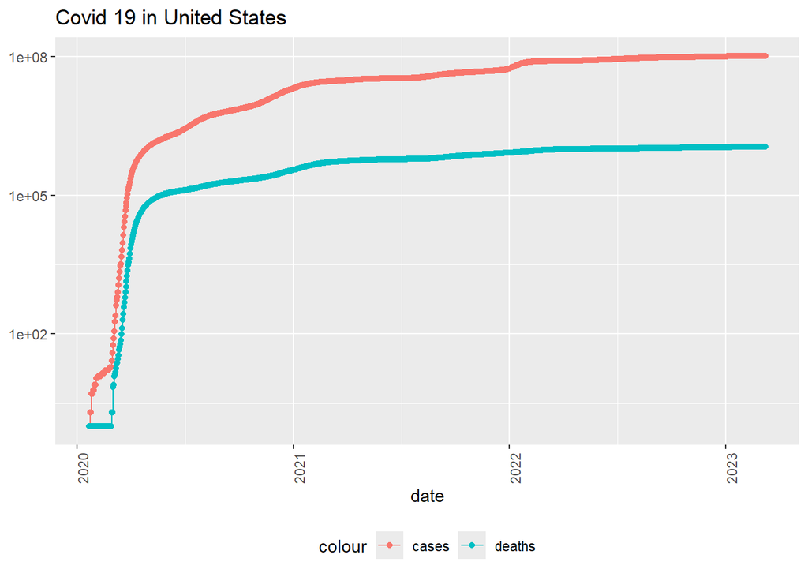

```r
US_totals %>%
  filter(cases > 0) %>%
  ggplot(aes(x = date, y = cases)) +
  geom_line(aes(color = "cases")) +
  geom_point(aes(color = "cases")) +
  geom_line(aes(y = deaths, color = "deaths")) +
  geom_point(aes(y = deaths, color = "deaths")) +
  scale_y_log10() +
  theme(legend.position = "bottom",
        axis.text.x = element_text(angle = 90)) +
  labs(title = "Covid 19 in United States", y = NULL)
```

## Visualization 2

Graph of Missouri Covid 19 cases and deaths.

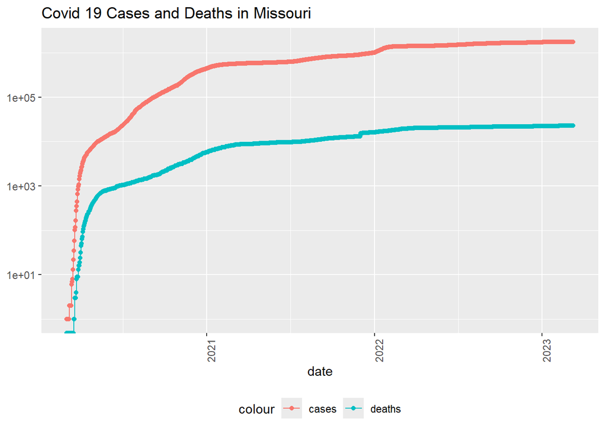

```r
state <- "Missouri"
US_by_state %>%
  filter(Province_State == state) %>%
  filter(cases > 0) %>%
  ggplot(aes(x = date, y = cases)) +
  geom_line(aes(color = "cases")) +
  geom_point(aes(color = "cases")) +
  geom_line(aes(y = deaths, color = "deaths")) +
  geom_point(aes(y = deaths, color = "deaths")) +
  scale_y_log10() +
  theme(legend.position = "bottom",
        axis.text.x = element_text(angle = 90)) +
  labs(title = str_c("Covid 19 Cases and Deaths in " , state), y = NULL)
```

```r
US_max_date <- max(US_totals$date)
US_max_deaths <- max(US_totals$deaths)

US_max_date
```

```
## [1] "2023-03-09"
```

```r
US_max_deaths
```

```
## [1] 1123836
```

# Analyzing Data

It looks like the number of cases and deaths taper off and almost flatlines. Is this true or not? I will investigate further.

Adding new variable and transform data again. Adding new_cases variable which is cases - lag(cases). Adding new_deaths variable which is deaths - lag(deaths).

```r
US_by_state <- US_by_state %>%
  mutate(new_cases = cases - lag(cases),
         new_deaths = deaths - lag(deaths))
US_totals <- US_totals %>%
  mutate(new_cases = cases - lag(cases),
         new_deaths = deaths - lag(deaths))
tail(US_totals %>%
       select(new_cases, new_deaths, everything()))
```

## Visualization 3

Now we can graph new cases and new deaths.

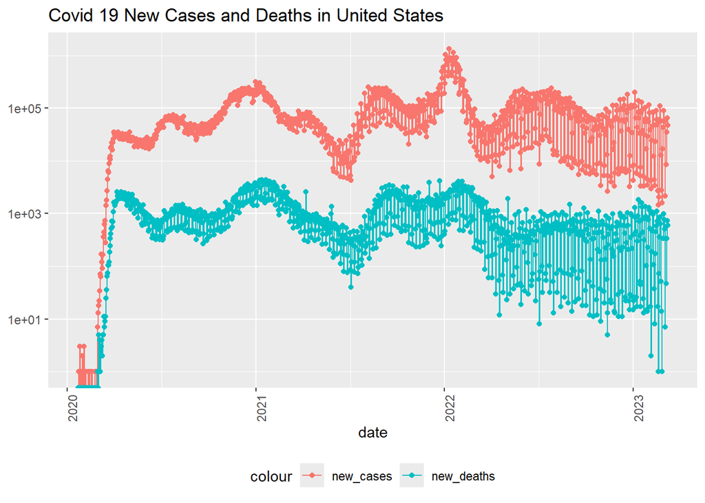

```r
US_totals %>%
  ggplot(aes(x = date, y = new_cases)) +
  geom_line(aes(color = "new_cases")) +
  geom_point(aes(color = "new_cases")) +
  geom_line(aes(y = new_deaths, color = "new_deaths")) +
  geom_point(aes(y = new_deaths, color = "new_deaths")) +
  scale_y_log10() +
  theme(legend.position = "bottom",
        axis.text.x = element_text(angle = 90)) +
  labs(title = "Covid 19 New Cases and Deaths in United States", y = NULL)
```

Now we can see the up and down trends in new cases and new deaths in more detail although the overall trend does look like it has flattened out. However, the number of new cases and new deaths reamin high.

## Visualization 4

Now lets look at the same graph for Missouri.

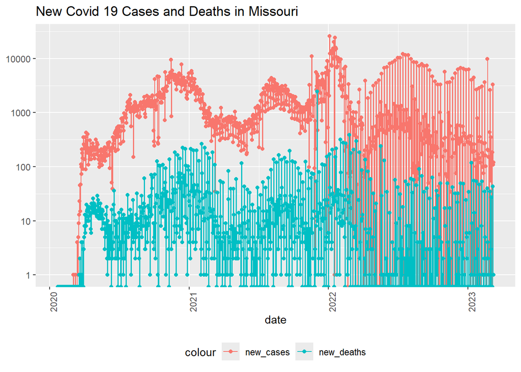

```r
state <- "Missouri"
US_by_state %>%
  filter(Province_State == state) %>%
  ggplot(aes(x = date, y = new_cases)) +
  geom_line(aes(color = "new_cases")) +
  geom_point(aes(color = "new_cases")) +
  geom_line(aes(y = new_deaths, color = "new_deaths")) +
  geom_point(aes(y = new_deaths, color = "new_deaths")) +
  scale_y_log10() +
  theme(legend.position = "bottom",
        axis.text.x = element_text(angle = 90)) +
  labs(title = str_c("New Covid 19 Cases and Deaths in " , state), y = NULL)
```

Missouri has a similar pattern of new covid 19 cases and new deaths to the United States totals. There is a dramatic increase in new cases and deaths at the end of 2021 followed by a dramatic decrease in new cases and deaths at the beginning of 2022. After the decrease in cases and deaths at the beginning of 2022 the cases gradually rise again and seem to level off. However, the number ofnew cases and new deaths remain high.

# Modeling Data

Lets look at a linear model of deaths_per_thousand being a function of cases_per_thousand in the US_state_totals data set.

Making US_state_totals data set to use with linear model.

```r
US_state_totals <- US_by_state %>%
  group_by(Province_State) %>%
  summarize(deaths = max(deaths), cases = max(cases),
            population = max(Population),
            cases_per_thou = 1000 * cases/ population,
            deaths_per_thou = 1000 * cases / population) %>%
  filter(cases >0, population > 0)
```

Now running the linear model of deaths per thousand as a function of cases per thousand.

```r
linear_model <- lm(deaths_per_thou ~ cases_per_thou, data = US_state_totals)

summary(linear_model)
```

```
##
## Call:
## lm(formula = deaths_per_thou ~ cases_per_thou, data = US_state_totals)
##
## Residuals:
##        Min         1Q     Median         3Q        Max
## -1.253e-14 -1.946e-15 -7.910e-16  2.950e-16  6.356e-14
##
## Coefficients:
##                  Estimate Std. Error    t value Pr(>|t|)
## (Intercept)    -6.077e-14  7.798e-15 -7.792e+00 2.13e-10 ***
## cases_per_thou  1.000e+00  2.497e-17  4.005e+16  < 2e-16 ***
## ---
## Signif. codes:  0 '***' 0.001 '**' 0.01 '*' 0.05 '.' 0.1 ' ' 1
##
## Residual standard error: 9.269e-15 on 54 degrees of freedom
## Multiple R-squared:      1,  Adjusted R-squared:      1
## F-statistic: 1.604e+33 on 1 and 54 DF,  p-value: < 2.2e-16
```

Find the number of cases that are the smallest.

```r
US_state_totals %>% slice_min(cases_per_thou)
```

Find the number of cases that are the largest.

```r
US_state_totals %>% slice_max(cases_per_thou)
```

Adding prediction column based on the linear model above to the data set.

```r
US_state_totals %>%
  mutate(pred = predict(linear_model))
```

Make new dataset US totals with predictions.

```r
US_totals_w_predictions <- US_state_totals %>%
  mutate(pred = predict(linear_model))
US_totals_w_predictions
```

## Model Visualization

Plotting actual deaths per thousand vs predicted deaths per thousand.

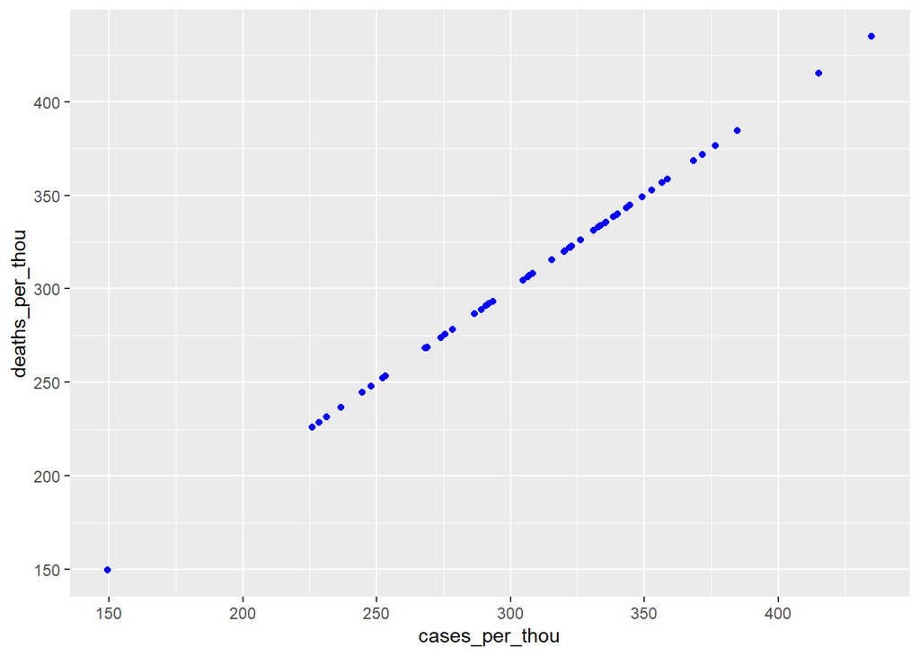

```r
US_totals_w_predictions %>%
  ggplot() +
  geom_point(aes(x = cases_per_thou, y = deaths_per_thou),
             color = "red") +
  geom_point(aes(x = cases_per_thou, y = pred), color = "blue")
```

# Conclusion